# Exercise 1 of “Big Data Analytics” (Winter Semester 2020/21)

# Task 2: Descriptive Statistics and R Basics

## a) Tutorial

The code for the R tutorial can be found in the file `Tutorial.R`.

## b) Standard deviation (1)

In case you forgot it, the formula for the sample standard deviation is $\sqrt{\frac{1}{n-1}\sum_{i=1}^n (x_i - \bar{x})^2}$. The implementation is trivial and does not need any comments ;-)

```r
stddev <- function(x, population = FALSE) {
  stopifnot(!any(is.na(x)))
  n <- length(x)
  result <- 0
  average <- mean(x)
  for (value in x) {
    result <- result + (value - average)^2
  }
  if (population) {
    result <- result / n
  } else {
    result <- result / (n - 1)
  }
  result <- sqrt(result)
  return(list(result = result, n = n))
}
```

Okay, still some comments, as this might be your first function ever in R: Though the task says something about parameter types, there are no type specifications in R. If you wanted, you could use the `class()` function to dynamically check types and throw an exception if something inappropriate is passed. We don’t do this here. However, as required by the task, we check for `NA`s. Fortunately, the function `is.na()` is vectorized, so we don’t need to loop over `x`. We just use `any()` to aggregate the resulting Boolean vector. `!` is the Boolean negation. The function `stopifnot()` basically allows to write `assert` statements, which throw an exception if violated. Also, note that we provide a default value for the parameter `population`, so the user does not need to specify it in the method call. The implementation of the formula itself is quite similar to other programming languages, apart from minor syntactic differences. For computing the mean, we use the built-in function instead of another loop. Using a `list` allows returning multiple values. Note that you don’t need to (but you can, if you want) quote the names of the list components when creating the list, which might be confusing for beginners.

## c) Standard deviation (2)

First, let us test how our function handles `NA`s.

```r
print(stddev(c(1, NA, 2)))
```

```
Error in stddev(c(1, NA, 2)) : !any(is.na(x)) is not TRUE
```

Well, this is what we expected. By the way, the built-in function either returns `NA` or removes `NA`s.

```r
print(sd(c(1, NA, 2)))
```

```
[1] NA
```

```r
print(sd(c(1, NA, 2), na.rm = TRUE))
```

```
[1] 0.7071068
```

Let’s write a “loop” which compares our function to the built-in one:

```r
differences <- sapply(1:100, function(i) {
  n <- runif(n = 1, min = 2, max = 100) # randomize vector length
  sd <- abs(rnorm(1)) # randomize target standard deviation
  x <- rnorm(n = n, sd = sd)
  return(sd(x) - stddev(x, population = FALSE)[["result"]])
})
```

Generating random numbers of a pre-defined distribution is really easy in R. In fact, we first choose the vector length uniformly random. Next, we randomly determine the standard deviation of our random vector. After generating the normally distributed vector, we finally compute the difference. Since our function returns a list, we need to extract the component containing the standard deviation. Also, as `sd()` computes the sample standard deviation, we do the same by setting `population` to `FALSE`. Else, it would be obvious that our function returns a different result. Instead of a loop, we use the `sapply()` function. It takes a vector/list and a function and applies the latter to each element of the former. In the past, the `apply` functions were also much faster than loops, but that isn’t true anymore. Anyway, they are still often used for loops when the iterations are independent from each other. Note that the passed function does not need to be pre-defined (though it could be), bu you can directly pass a new anonymous function.

We should have a look at the resulting vector:

```r
print(summary(differences))
```

```
      Min.    1st Qu.     Median       Mean    3rd Qu.       Max.
-4.441e-16  0.000e+00  0.000e+00  3.003e-17  2.776e-17  8.882e-16
```

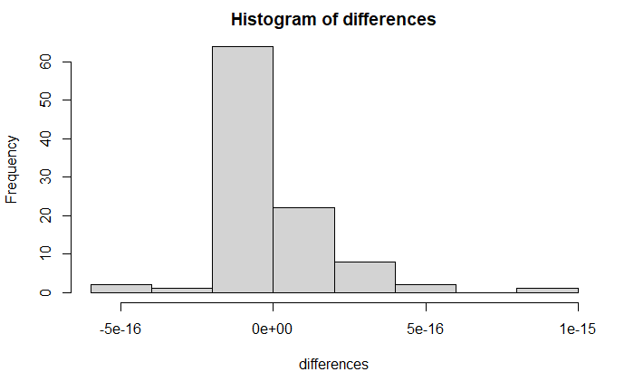

```r
hist(differences)
```

Looks good, there are only minor numerical differences, which can always occur in floating-point operations. By the way, if you repeatedly run the code, results change slightly, because of the random number generation. Use `set.seed()` to initialize the RNG in a reproducible manner.

## d) Standard deviation (3)

We first implement the vectorized version of the function. This also makes the function more readable (as least if you are used to R / thinking in vectors):

```r
stddev_vectorized <- function(x, population = FALSE) {
  stopifnot(!any(is.na(x)))
  n <- length(x)
  average <- mean(x)
  result <- sum((x - average)^2)
  if (population) {
    result <- result / n
  } else {
    result <- result / (n - 1)
  }
  result <- sqrt(result)
  return(list(result = result, n = n))
}
```

Here comes the benchmark:

```r
library(microbenchmark)
x <- rnorm(10000)
print(microbenchmark(sd(x), stddev(x), stddev_vectorized(x), times = 1000))
```

```
Unit: microseconds
```

| expr | min | lq | mean | median | uq | max | neval | cld |
| --- | --- | --- | --- | --- | --- | --- | --- | --- |
| sd(x) | 46.2 | 47.90 | 58.6310 | 50.40 | 63.65 | 210.8 | 1000 | a |
| stddev(x) | 407.2 | 416.35 | 543.8300 | 442.20 | 553.95 | 4201.3 | 1000 | c |
| stddev_vectorized(x) | 63.8 | 66.00 | 115.6396 | 91.25 | 113.10 | 9984.9 | 1000 | b |

Our vectorized function is clearly better than the loop-based one, but worse than the built-in one. Key take-away: Avoid writing loops in R for fast-running, low-level code. Always search if there is a vectorized alternative. The built-in functions are partly implemented in C and Fortran, so they are way better in number crunching. You can also easily use code from other languages in R on your own. For example, the `Rcpp` package enables integration of C++ code and also has a lot of syntactic sugar to represent R data structures like vectors or lists in C++ code.

## e) Plots (1)

We first get an overview of the [`iris` dataset](https://en.wikipedia.org/wiki/Iris_flower_data_set). We don’t need to load the dataset explicitly, as it is part of the `datasets` package, which is pre-loaded by default.

```r
summary(iris)
```

[output not shown]

There are four numeric attributes describing the flower and one categorical attribute containing the name of the species.

Using the built-in plot functionality is straightforward. In fact, if you don’t want additional styling, you just need to pass the attribute(s) you want to plot.

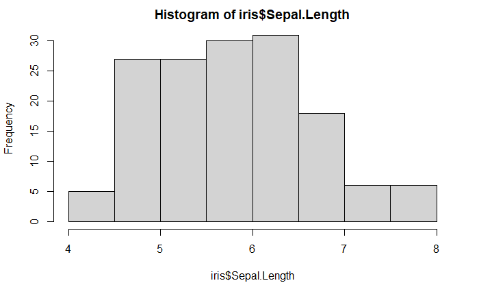

```r
hist(iris$Sepal.Length, breaks = 10)
```

In the histogram, `breaks` can also be a vector of break points. For example, you can use `seq()` to create equal-width bins. If you just pass the number of bins, according to `help(hist)`, “the number is a suggestion only; as the breakpoints will be set to `pretty` values”. Indeed, R has a function `pretty()` to compute breakpoints.

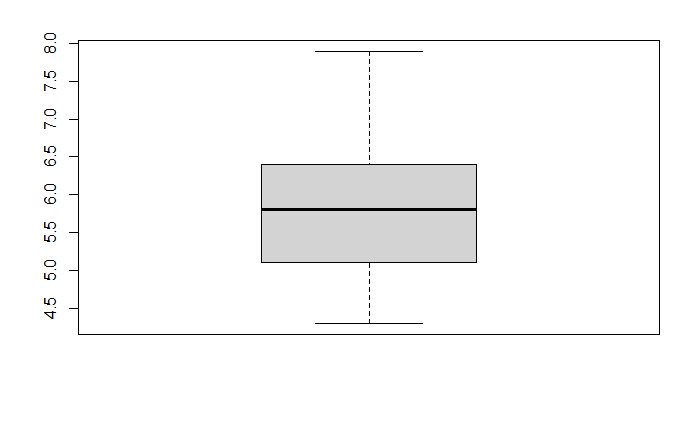

```r
boxplot(iris$Sepal.Length)
```

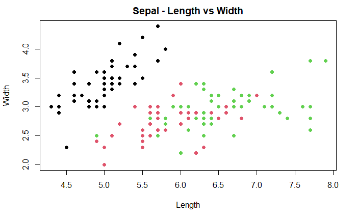

```r
plot(iris$Sepal.Length, iris$Sepal.Width, col = iris$Species, pch = 16,
     main = "Sepal - Length vs Width", xlab = "Length", ylab = "Width")
```

For the scatter plot, we add some styling. `pch` (plot character) denotes the symbol used for the points. Only some of the symbol types are filled, for others just the outline is colored. Note that `col` does not denote a specific color here, but rather the vector which should determine how to color. You could also transform the categories into your color names of choice and then pass the actual coloring.

## f) Plots (2)

`gpplot2` might look slightly more complicated at the beginning, but actually is well structured. Also, we again add some styling, so the code naturally becomes longer.

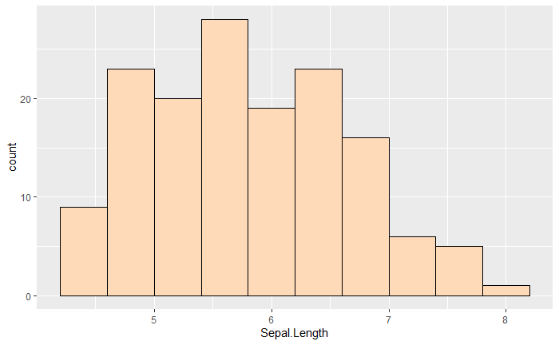

```r
library(ggplot2)
ggplot(data = iris) +
  geom_histogram(mapping = aes(x = Sepal.Length), fill = "#FFDAB9", color = "black",
                 bins = 10)
```

Here, the histogram takes our number of bins at face value instead of creating a more pretty number. `geom_histogram()` also allows to specify break points with the argument `breaks`. Note the difference between `fill` and `color`: The former is used for areas, the latter for the outline. You can specify colors by name and RGB code.

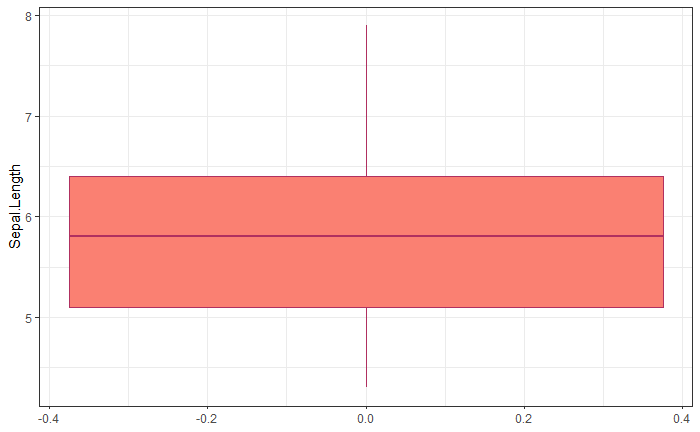

```r
ggplot(data = iris) +
  geom_boxplot(mapping = aes(y = Sepal.Length), color = "maroon", fill = "salmon") +
  theme_bw() # remove gray background
```

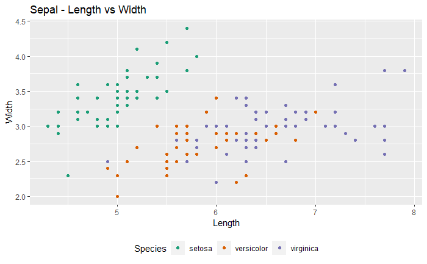

```r
ggplot(data = iris) +
  geom_point(mapping = aes(x = Sepal.Length, y = Sepal.Width, color = Species)) +
  theme(legend.position = "bottom") +
  scale_color_brewer(palette = "Dark2") +
  ggtitle("Sepal - Length vs Width") +
  xlab("Length") +
  ylab("Width")
```

In the scatter plot, note the `color` is now within `aes()`. This means it is not set to a fixed value, but depends on the data. By calling a `scale_color_...()` function, you can provide the color mapping. For example, [Color Brewer](https://colorbrewer2.org/) has some nice color schemes. `scale_color_manual()` allows to create an arbitrary mapping with your colors of choice.